# 在线课程-网络结构数据 TASK2 使用igraph包创建网络

狗熊会

R语言中的igraph包可以用来解决网络问题并进行可视化。igraph包的功能十分强大，它可以快速轻松地创建、绘制和分析无向图及有向图。igraph包的内容也是十分丰富，接下来就对igraph包的内容进行学习。

任务介绍：本任务主要学习如何使用R语言中的igraph包创建网络。

这个案例的学习目标包括：

1. 学习如何使用R语言创建网络；
2. 学习邻接矩阵的相关概念，并学习如何使用R语言生成邻接矩阵；

### 准备工作

```r
#清除工作环境
cat("\014");rm(list=ls())
```

```r
#加载相应的包,若没有,请先用 install.packages("igraph") 命令安装
library(igraph)
```

### 任务一: 使用igraph包创建网络（新建空网络—添加网络节点—添加网络连边）

首先学习如何使用R语言中igraph包新建一个空网络，并逐步添加网络节点和网络连边。下面介绍使用的函数：

1. 创建空网络：R语言igraph包中新建空网络使用的函数为`make_empty_graph(n=0,directed)`或`graph.empty(n=0,directed)`。其中,参数n表示创建网络的节点数，n为0时表示创建的是空网络，不包括任何节点；另一个参数directed用来设定网络是有向还是无向的，TRUE表示有向，FALSE表示无向，R默认创建的是有向网络。
2. 添加网络节点：R语言igraph包中添加网络节点使用的函数为`add_vertices(graph, nv, ..., attr)`。 该函数主要包括graph和nv两个参数，其中参数graph表示需要添加节点的网络图，nv表示添加节点的个数。此外，可输入其他一些参数以设定节点的颜色和属性等。
3. 添加网络连边：R语言igraph包中添加网络连边使用的函数为`add_edges(graph, edges, ..., attr = list())`。该函数主要包括graph和edges两个参数，graph表示需要添加连边的网络图，edges表示需要添加的边，其输入形式是一个长度为偶数的网络节点序列，从第一个节点开始，每两个节点表示一条边，若网络图为有向图，边由每组的奇数项节点指向偶数项节点。此外，也可以输入一些其他参数设置边的颜色和属性等。

```r
set.seed(1)                                  # 生成随机数种子，使每次绘制出的图相同
g = make_empty_graph()                       # 创建空网络
g                                            # 查看网络
```

```
## IGRAPH 267bce3 D--- 0 0 --
## + edges from 267bce3:
```

```r
par(mfrow = c(1,2))                          # 将画布分成一行两列
g = add_vertices(g, 6)                       # 添加6个节点
g                                            # 查看网络结构
```

```
## IGRAPH 267da18 D--- 6 0 --
## + edges from 267da18:
```

```r
plot(g, main = '添加节点')                   # 画网络图

g = add_edges(g, c(1,2, 2,3,1,3,3,4,4,5,1,5,3,6,2,6,5,6))          # 添加连边
g                                                                  # 查看网络结构
```

```
## IGRAPH 26827ed D--- 6 9 --
## + edges from 26827ed:
## [1] 1->2 2->3 1->3 3->4 4->5 1->5 3->6 2->6 5->6
```

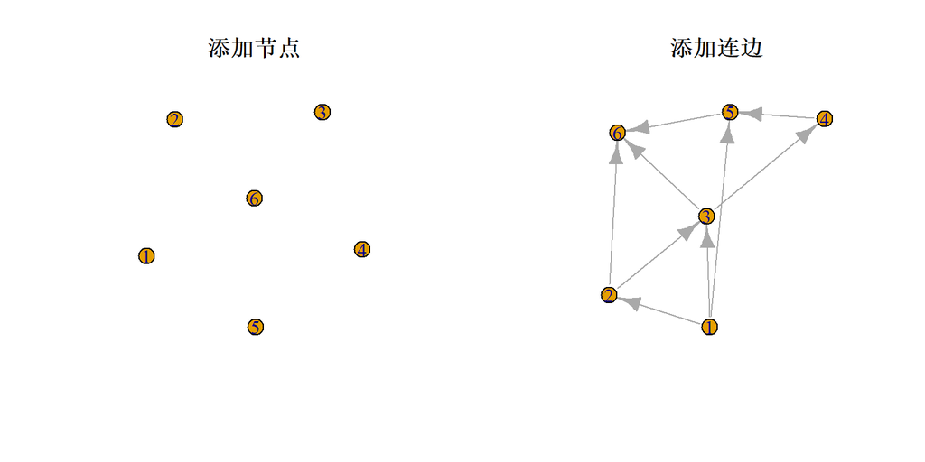

```r
plot(g, main = '添加连边')                                         # 画网络图
```

上面代码具体实现了R语言igraph包生成空网络并添加节点和连边，每一步网络的输出结果中第一行的两个数字分别表示节点数和连边数，如第一步生成空网络，节点数和连边数均为0；添加6个节点后，节点数变为6，但连边数仍为0；添加连边后，连边数变为9。网络图则更清晰的展示了此网络的生成过程。

### 任务二: 利用边数据构建（有向、无向）网络

任务一中我们学习了如何使用R语言中igraph包创建空网络并添加节点和连边，但事实上大多数时候，我们都是根据已知的边数据来构建网络，所以任务二将介绍如何利用边数据构建网络。

R语言igraph包中根据边数据构建网络使用的函数主要有以下两个：

1. `graph_from_edgelist(el, directed = TRUE)`：参数el表示边数据，注意此函数中边数据必须以列数为2的矩阵格式输入；directed的参数值TRUE和FALSE分别表示网络为有向图还是无向图，默认为有向图。
2. `graph_from_data_frame(d, directed = TRUE, vertices = NULL)`：参数d表示边序列，格式为数据框；directed同样表示是否为有向图；vertices格式为数据框，用于设定节点属性，默认NULL，即将数据框d的前两列作为边序列，其他列作为边的属性，节点的名称按照边序列来确定。

下面将用上述两个函数分别实现Zachary网络的构建，使用的数据为karate数据。Zachary网络是对一个美国大学空手道俱乐部进行观测而构建的一个社会网络，共包含34个节点和78条边,其中每个节点表示俱乐部中的一个成员,而边表示成员之间的友谊关系。karate数据集共2列、78行，其中每个序号代表该网络中的一个成员，每一行代表两个成员之间存在友谊关系。

```r
data = read.table("karate.txt",head = FALSE)                   # 导入空手道俱乐部边数据

set.seed(800)                                                  # 生成随机数种子，使每次绘制出的图相同
par(mfrow = c(1,2))                                            # 将画布分成一行两列
g1 = graph_from_edgelist(as.matrix(data),directed = FALSE)     # 用graph_from_edgelist()函数创建无向网络
g1                                                             # 查看网络结构
```

```
## IGRAPH 2694d5f U--- 34 78 --
## + edges from 2694d5f:
##  [1]  1-- 2  1-- 3  1-- 4  1-- 5  1-- 6  1-- 7  1-- 8  1-- 9  1--11  1--12
## [11]  1--13  1--14  1--18  1--20  1--22  1--32  2-- 3  2-- 4  2-- 8  2--14
## [21]  2--18  2--20  2--22  2--31  3-- 4  3-- 8  3-- 9  3--10  3--14  3--28
## [31]  3--29  3--33  4-- 8  4--13  4--14  5-- 7  5--11  6-- 7  6--11  6--17
## [41]  7--17  9--31  9--33  9--34 10--34 14--34 15--33 15--34 16--33 16--34
## [51] 19--33 19--34 20--34 21--33 21--34 23--33 23--34 24--26 24--28 24--30
## [61] 24--33 24--34 25--26 25--28 25--32 26--32 27--30 27--34 28--34 29--32
## [71] 29--34 30--33 30--34 31--33 31--34 32--33 32--34 33--34
```

```r
plot(g1,main = "无向网络图",vertex.label.cex = 0.6)            # 画无向网络图

g2 = graph_from_data_frame(data,directed = TRUE)               # 用graph_from_data_frame()函数创建有向网络

g2                                                             # 查看网络结构
```

```
## IGRAPH 26987ce DN-- 34 78 --
## + attr: name (v/c)
## + edges from 26987ce (vertex names):
##  [1] 2 ->1  3 ->1  4 ->1  5 ->1  6 ->1  7 ->1  8 ->1  9 ->1  11->1  12->1
## [11] 13->1  14->1  18->1  20->1  22->1  32->1  3 ->2  4 ->2  8 ->2  14->2
## [21] 18->2  20->2  22->2  31->2  4 ->3  8 ->3  9 ->3  10->3  14->3  28->3
## [31] 29->3  33->3  8 ->4  13->4  14->4  7 ->5  11->5  7 ->6  11->6  17->6
## [41] 17->7  31->9  33->9  34->9  34->10 34->14 33->15 34->15 33->16 34->16
## [51] 33->19 34->19 34->20 33->21 34->21 33->23 34->23 26->24 28->24 30->24
## [61] 33->24 34->24 26->25 28->25 32->25 32->26 30->27 34->27 34->28 32->29
## [71] 34->29 33->30 34->30 33->31 34->31 33->32 34->32 34->33
```

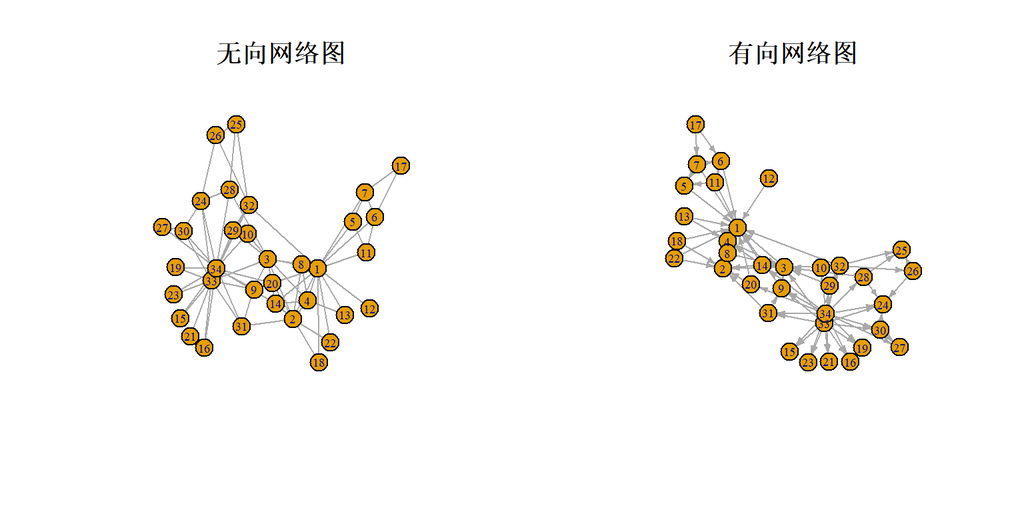

```r
plot(g2,edge.arrow.size =0.3,main = "有向网络图",              # 画有向网络图
     vertex.label.cex = 0.6)                                   # 修改节点标签大小
```

对比g1和g2的网络结构输出结果可知，二者节点数和连边数相同，仅有连边是否由箭头表示的差异，这就是directed参数作用的结果。网络图中也可以清晰地看到有向网络中连边由一个节点指向另一个节点。

**注：**Zachary网络是一个无向网络，为了体现有向网络的创建方法才将g2设置为有向网络。

### 课后作业

- 数据集说明：College Football网络是根据美国大学生足球联赛创建的一个真实的社会网络。该网络中的节点代表足球队,连边表示两只球队之间进行过一场比赛。
- 作业一：找到football.csv数据，尝试利用该数据使用`graph_from_data_frame()`构建网络。
- 作业二：对生成的网络做适当解读。
- 选做：找到game of thrones文件夹中的got-edges.csv数据，尝试利用该数据使用`graph_from_data_frame()`构建无向网络。（数据集说明：该数据为George R. R. Martin的《A Storm of Swords》中人物关系的网络数据，其中每个节点表示不同的角色，边代表这些角色是否同时出现。）